# Data Translation Assignment

Lynna Tran

2/21/2021

```r
####LOAD LIBRARIES####
library(tidyverse)
library(jtools)
library(car)
library(readr)
library(purrr)
library(lubridate)
####IMPORT DATA####
Scorecard <- read.csv("Lab3_Rawdata/Most+Recent+Cohorts+(Scorecard+Elements).csv")

name_id <- read_csv("Lab3_Rawdata/id_name_link.csv") %>%
  distinct(schname, .keep_all = TRUE) %>%
  rename(OPEID = opeid) %>%
  rename(UNITID = unitid)
```

```r
prepend <- function(fname) {
    paste('Lab3_Rawdata/', fname, sep = '')
  }

trends <- list.files(path = 'Lab3_Rawdata', pattern = 'trends_up_to_') %>%
  map(prepend) %>%
  map(read_csv) %>%
  reduce(rbind)
####MERGE DATA####
name_trends_scorecard    <- inner_join(name_id, Scorecard, by = 'OPEID', 'UNITID') %>%
  inner_join(trends, by = 'schname')
```

```r
####FILTERING COLLEGES ####
#Colleges that predominantly grant bachelors degrees
bachelors_colleges <- name_trends_scorecard %>%
  filter(PREDDEG == 3) %>%
  select(OPEID, UNITID.x, schname, keyword , keynum, monthorweek , index,  md_earn_wne_p10.REPORTED.EARNINGS)

##Earnings of colleges, adding median earnings columns after filtering
college_earnings <- bachelors_colleges %>%
  filter(md_earn_wne_p10.REPORTED.EARNINGS != 'NULL') %>%
  filter(md_earn_wne_p10.REPORTED.EARNINGS != 'PrivacySuppressed') %>%
  mutate(median_earnings = as.numeric(md_earn_wne_p10.REPORTED.EARNINGS))

##Checking median earnings values for overall college median earnings
overall_median_earnings <- median(college_earnings$median_earnings)

##Adding dependent variables to be tested such as High Earning Dummy Variable and SD index based off of schname and index
##adds t/f for high earning and low earning
interested_colleges <- college_earnings %>%
  mutate(high_earning = median_earnings > 41800) %>%
  mutate(low_earning  = median_earnings < 41799) %>%
  filter(!is.na(index)) ##filtering out NA indexes because if there's no index value, we can't use it anyways

##adding sd index
sd_index_colleges <- interested_colleges %>%
  group_by(schname, keynum) %>%
  summarise(sd_index = (index - mean(index)) / sd(index), schname,
            keyword, monthorweek, keynum, median_earnings, sd_index, high_earning, low_earning)
```

When filtering colleges that I’m using in my dataset, I keep all the colleges that colleges that predominantly grant bachelor’s degrees. Because I will be comparing the median earnings between colleges, any colleges that have values of ‘Null’ or ‘PrivacySuppressed’ will also be filtered out. These values won’t be adding any value to my dataset so it’s ok for me to filter them out since I’m not ‘losing’ any median earning data if I didn’t have them in the first place.

To define whether a school is considered a high-earning college as relative to a low-earning college, I analyzed all the available median earnings of graduates ten years after graduation for each college. From the list of median earnings, I found the median of the median earnings. Therefore, I knew the median of the college’s median earnings was 41,800. Because of that, I concluded that if a school’s median earnings is above 41,800, they are considered a high-earning college. Vice versa, if a school’s median earnings is less than 41,799, they are considered a low-earning college. Using that as the citeria, I was able to make a binary variable for whether a school is considered high-earning or not. That will act at my dummy variable going forward.

The Google Trends indices are comparable only to themselves. Because of that, I chose to group my dataset by name and then keynum. It was important to include both the school name and the keyword since keywords can differ for each school. Once my dataset is grouped appropriately, I standardize the index to make it easier to compare between keynums. I wanted to do it on the key num level early on in my data wrangling because the index describes the instances of each key num, per school.

```r
###GROUP BY DATE ####
college_information <- interested_colleges %>%
  select(schname ,median_earnings, high_earning) %>%
  distinct(schname ,median_earnings, high_earning)

college_sdindex_year2013 <- sd_index_colleges %>%
  mutate(DATE = substr(monthorweek, 1, 10)) %>%
  mutate(DATE = as.Date(DATE))  %>%
  select(schname, keynum, sd_index, DATE, median_earnings, high_earning) %>%
  filter(between(DATE, as.Date("2013-03-24"), as.Date("2013-12-31"))) %>%
  group_by(schname) %>%
  summarise(sd_index2013 = sum(sd_index))

college_sdindex_year2014 <- sd_index_colleges %>%
  mutate(DATE = substr(monthorweek, 1, 10)) %>%
  mutate(DATE = as.Date(DATE))  %>%
  select(schname, keynum, sd_index, DATE, median_earnings, high_earning) %>%
  filter(between(DATE, as.Date("2014-01-01"), as.Date("2014-12-31"))) %>%
  group_by(schname) %>%
  summarise(sd_index2014 = sum(sd_index))

college_sdindex_year2015 <- sd_index_colleges %>%
  mutate(DATE = substr(monthorweek, 1, 10)) %>%
  mutate(DATE = as.Date(DATE))  %>%
  select(schname, keynum, sd_index, DATE, median_earnings, high_earning) %>%
  filter(between(DATE, as.Date("2015-01-01"), as.Date("2015-12-31"))) %>%
  group_by(schname) %>%
  summarise(sd_index2015 = sum(sd_index))

college_sdindex_year2016 <- sd_index_colleges %>%
  mutate(DATE = substr(monthorweek, 1, 10)) %>%
  mutate(DATE = as.Date(DATE))  %>%
  select(schname, keynum, sd_index, DATE, median_earnings, high_earning) %>%
  filter(between(DATE, as.Date("2016-01-01"), as.Date("2016-12-31"))) %>%
  group_by(schname) %>%
  summarise(sd_index2016 = sum(sd_index))

college_sdindex_year <- left_join(college_sdindex_year2013, college_sdindex_year2014, by = 'schname') %>%
  left_join(college_sdindex_year2015, by = 'schname') %>%
  left_join(college_sdindex_year2016, by = 'schname') %>%
  left_join(college_information, by = 'schname')
```

I chose to analyze my data at the year level. I thought it will be easier to subset my data that way instead of leaving it at the weekly data. That way, I can get the whole picture of how the standardized index is changing year by year, instead of partitioning it by week. I built a new dataset for every year by filtering on the dates to ensure that only data from that year is shown. I chose to sum the standardized index, grouped by year because logically, it made sense that the changes of the standardized index per week can be summed up altogether to display the changes from the year. That way, I’m only left with one standardized index per year. If a school’s year standardized index is negative, it means that there was less keywords getting searched as compared within the school’s keywords as opposed to a positive year standardized index. After builting the dataset filtered for each year, I combined them together into one big dataset. That way, each school will have a value of standardized index for each year.

```r
###2013 MODEL
sd_index_model2013 <- lm(data = college_sdindex_year, median_earnings ~ sd_index2013)

sd_index_model2013HE <- lm(data = college_sdindex_year, median_earnings ~ sd_index2013  + high_earning)


###2014 MODEL
sd_index_model2014 <- lm(data = college_sdindex_year, median_earnings ~ sd_index2014)

sd_index_model2014HE <- lm(data = college_sdindex_year, median_earnings ~ sd_index2014  + high_earning)



###2015 MODEL
sd_index_model2015 <- lm(data = college_sdindex_year, median_earnings ~ sd_index2015)

sd_index_model2015HE <- lm(data = college_sdindex_year, median_earnings ~ sd_index2015  + high_earning)


###2016 MODEL
sd_index_model2016 <- lm(data = college_sdindex_year, median_earnings ~ sd_index2016)

sd_index_model2016HE <- lm(data = college_sdindex_year, median_earnings ~ sd_index2016  + high_earning)
```

After I combined all the years’ (2013-2016) standardized index into one dataset for each school name, I have a ‘tidy’ dataset that I’m able to run models on. I built models based on the median earnings of each school and their standardized indexes, by year. That way, I’m comparing the school’s standardized index with other school’s standardized index of the same year. I produced one model for each year without our dummy variable of high-earning college or not, and one model with the dummy variable. It was important to include the dummy variable because our research question is student interest between a high-earning school, relative to a low-earning school.

```r
export_summs(sd_index_model2013, sd_index_model2014, sd_index_model2015, sd_index_model2016)
```

|  | Model 1 | Model 2 | Model 3 | Model 4 |
| --- | --- | --- | --- | --- |
| (Intercept) | 40655.12 *** | 42068.22 *** | 40115.72 *** | 41766.51 *** |
|  | (356.29) | (291.80) | (369.21) | (310.87) |
| sd_index2013 | 55.50 *** |  |  |  |
|  | (7.06) |  |  |  |
| sd_index2014 |  | 58.50 *** |  |  |
|  |  | (14.16) |  |  |
| sd_index2015 |  |  | -76.28 *** |  |
|  |  |  | (8.17) |  |
| sd_index2016 |  |  |  | -82.57 *** |
|  |  |  |  | (17.20) |
| N | 1800 | 1800 | 1800 | 1800 |
| R2 | 0.03 | 0.01 | 0.05 | 0.01 |
| *** p < 0.001; ** p < 0.01; * p < 0.05. |  |  |  |  |

```r
export_summs(sd_index_model2013HE, sd_index_model2014HE, sd_index_model2015HE, sd_index_model2016HE)
```

|  | Model 1 | Model 2 | Model 3 | Model 4 |
| --- | --- | --- | --- | --- |
| (Intercept) | 34335.54 *** | 34602.81 *** | 34131.86 *** | 34572.46 *** |
|  | (294.80) | (268.97) | (300.49) | (276.35) |
| sd_index2013 | 15.79 ** |  |  |  |
|  | (5.11) |  |  |  |
| high_earningTRUE | 16652.16 *** | 16801.72 *** | 16533.86 *** | 16789.41 *** |
|  | (397.10) | (391.55) | (397.91) | (393.15) |
| sd_index2014 |  | 26.82 ** |  |  |
|  |  | (9.98) |  |  |
| sd_index2015 |  |  | -25.11 *** |  |
|  |  |  | (5.97) |  |
| sd_index2016 |  |  |  | -25.51 * |
|  |  |  |  | (12.19) |
| N | 1800 | 1800 | 1800 | 1800 |
| R2 | 0.51 | 0.51 | 0.51 | 0.51 |
| *** p < 0.001; ** p < 0.01; * p < 0.05. |  |  |  |  |

When comparing the models without the dummy variables to the models that include the dummy variables, the co-efficient do change for each model. That makes sense for our analysis because it shows that the dummy variable was included previously in our error term and by using the dummy variable in the models, we are accurately describing the effect of whether a school being high-earning or low-earning will effect student interest. This is a good sign that we should use the dummy variables models when we are conducting the rest of our analysis. By looking at the 2nd coefficient table that compares the yearly models with the dummy variables, we can make these conclusions:

If a school is considered high-earning, the median earnings of a graduate after 10 years increases as compared to a school that is considered low-earning. - In 2013: A 10-year high-earning school graduate makes $16,652 more than a graduate from a low-earning school. - In 2014: A 10-year high-earning school graduate makes $16,801 more than a graduate from a low-earning school. - In 2015: A 10-year high-earning school graduate makes $16,533 more than a graduate from a low-earning school. - In 2016: A 10-year high-earning school graduate makes $16,789 more than a graduate from a low-earning school.

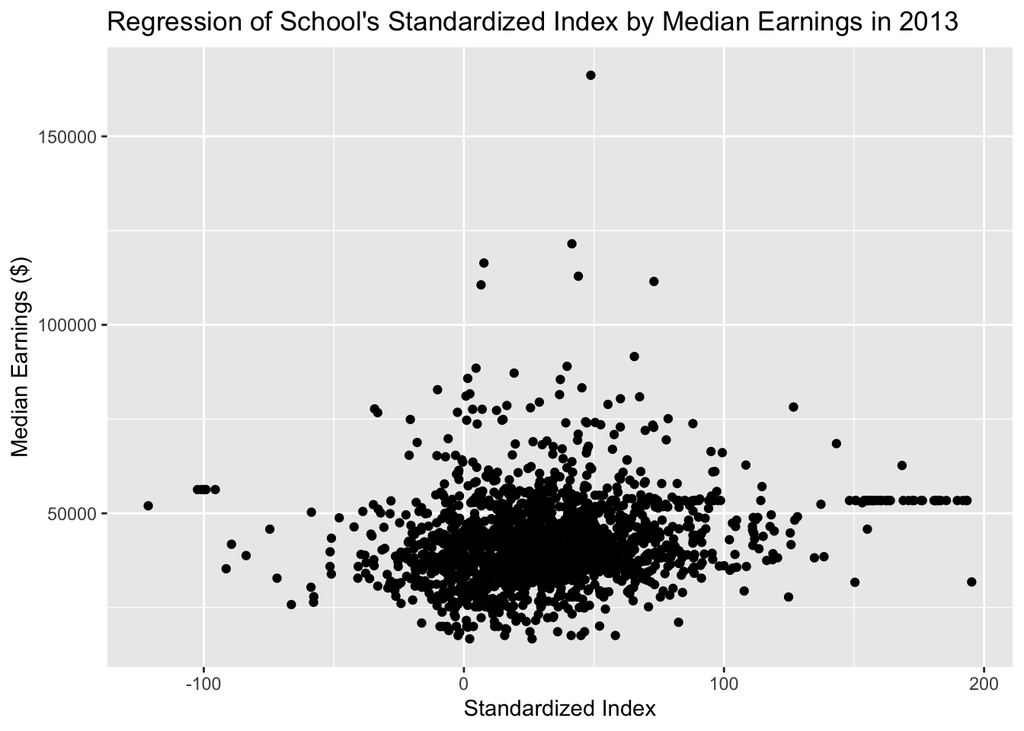

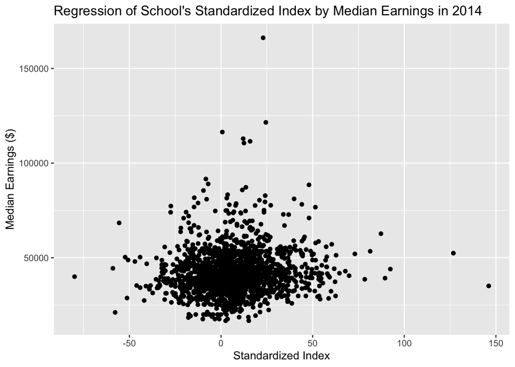

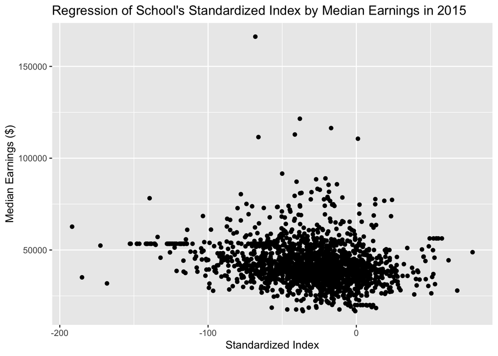

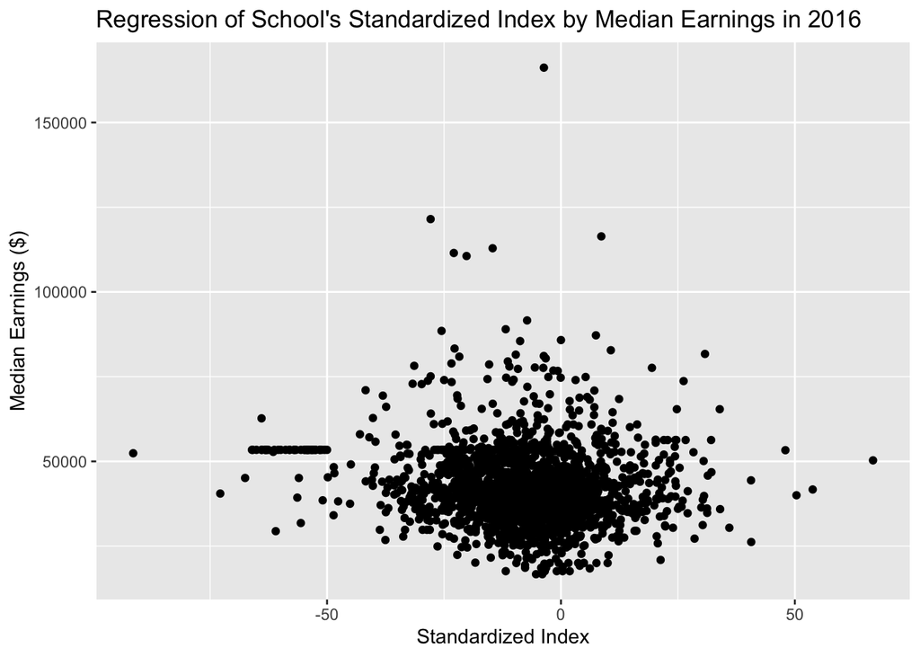

[figure not shown]

Overall, our conclusions is that if a school is considered high-earning, the median earnings of a graduate after 10 years increases as compared to a school that is considered low-earning. This is supported by the yearly model between 2013-2016 all having positive relationships between the median earnings and whether the school is considered high-earning. It is harder to conclude if a school’s median earnings is related to student interest as given by Google Trends index. We see the relationship change between the yearly models which means to us that they are other variables in the error term that have impact on a school’s median earning. We will not be able to successfully conclude if more student interest is related to median’s earnings by just looking at these two variables.